# 260-2017-08-28-functional-methods

2017-08-31 11:12:06

## Prelude

[video not shown]

[(Han et al. 2017)](http://doi.org/10.1016/j.cell.2016.12.027)

## Spatial and Temporal Resolution

[figure not shown]

[(Sejnowski, Churchland, and Movshon 2014)](http://doi.org/10.1038/nn.3839)

## Which of the following statements about the brain imaging technique used in this figure is FALSE?

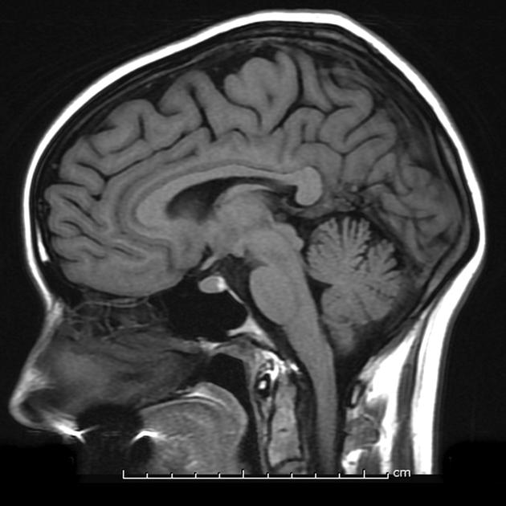

## Which of the following statements about the brain imaging technique used in this figure is FALSE?

- A. It is non-invasive.
- B. It provides information about brain structures.
- C. It provides information about rapid (millisecond-level) changes in brain activity.
- D. It cannot resolve details about individual neurons.

## Which of the following statements about the brain imaging technique used in this figure is FALSE?

- A. It is non-invasive.
- B. It provides information about brain structures.
- **C. It provides information about rapid (millisecond-level) changes in brain activity.**
- D. It cannot resolve details about individual neurons.

## Anterograde tracing chemicals are injected in brain tissue in order to answer what question?

- A. What kinds of cells are prominent in a given area?
- B. The density of dendrites and axons in a given region?
- C. Where does a target region project to or connect with?

## Anterograde tracing chemicals are injected in brain tissue in order to answer what question?

- A. What kinds of cells are prominent in a given area?
- B. The density of dendrites and axons in a given region?
- **C. Where does a target region project to or connect with?**

## Diffusion Tensor Imaging (DTI) is one type of X imaging?

- A. functional PET
- B. structural CT
- C. structural MRI
- D. functional MRI (fMRI)

## Diffusion Tensor Imaging (DTI) is one type of X imaging?

- A. functional PET
- B. structural CT
- **C. structural MRI**
- D. functional MRI (fMRI)

## Today's topics

- Functional methods

## Functional methods

- Recording from the brain
- Interfering with the brain
- Stimulating the brain
- Simulating the brain

## ￼Recording from the brain

- Single/multi unit recording
- Microelectrodes
- Small numbers of nerve cells

## Single/multi-unit Recording

[figure not shown]

http://www.nature.com/nrn/journal/v5/n11/images/nrn1535-i1.jpg

## Single/multi-unit recording

- What does neuron X respond to?
- Great temporal (ms), spatial resolution (um)
- Invasive
- Rarely suitable for humans, but…

## [Electrocorticography (ECoG)](https://en.wikipedia.org/wiki/Electrocorticography)

[figure not shown]

[video not shown]

## [Positron Emission Tomography (PET)](https://en.wikipedia.org/wiki/Positron_emission_tomography)

[video not shown]

## [Positron Emission Tomography (PET)](https://en.wikipedia.org/wiki/Positron_emission_tomography)

- Radioactive tracers (glucose, oxygen)
- Positron decay
- Experimental condition - control
- Average across individuals

[figure not shown]

## PET

- Evaluating PET
  - Temporal (~ s) and spatial (mm-cm) resolution worse than fMRI
  - Radioactive exposures + mildly invasive
  - Dose < airline crew exposure in 1 yr

## [Functional Magnetic Resonance Imaging (fMRI)](https://en.wikipedia.org/wiki/Functional_magnetic_resonance_imaging)

- Neural activity -> local \(O_2\) consumption increase
- Blood Oxygen Level Dependent (BOLD) response
  - Oxygenated vs. deoxygenated hemoglobin creates magnetic contrast
  - Do regional blood \(O_2\) levels (and flow) vary with behavior X?

## fMRI

[figure not shown]

## fMRI [(Dougherty et al. 2003)](http://doi.org/10.1167/3.10.1)

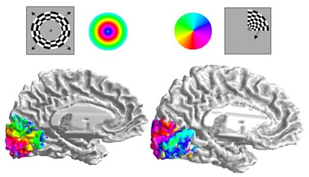

## fMRI

- Evaluating
  - Non-invasive, but expensive
  - Moderate but improving (mm) spatial, temporal (~sec) resolution
  - **Indirect** measure of brain activity
- [Hemodynamic Response](https://en.wikipedia.org/wiki/Haemodynamic_response) Function (HRF)
  - 1s delay plus 3-6 s ramp-up

## [Hemodynamic Response](https://en.wikipedia.org/wiki/Haemodynamic_response) Function (HRF)

[figure not shown]

## [Electroencephalography (EEG)](https://en.wikipedia.org/wiki/Electroencephalography)

- How does it work?
  - Electrodes on scalp or brain surface
- What do we measure?
  - Combined activity of huge # of neurons

## EEG

[figure not shown]

## EEG

- High temporal, poor spatial resolution
- Analyze frequency bands
  - LOW: deep sleep
  - MIDDLE: Quiet, alert state
  - HIGH:“Binding” information across senses

## EEG Frequency

[figure not shown]

## [Event-related potentials (ERPs)](https://en.wikipedia.org/wiki/Event-related_potential)

- EEGs time-locked to some event - Averaged over many trials

## ERPs

[figure not shown]

## [Brain Computer Interface (BCI)](http://computer.howstuffworks.com/brain-computer-interface.htm)

[figure not shown]

http://s.hswstatic.com/gif/brain-computer-interface-3.gif

## [Magneto-encephalography (MEG)](https://en.wikipedia.org/wiki/Magnetoencephalography)

- Like EEG, but measuring magnetic fields
- High temporal resolution, low spatial resolution
- Magnetic field propagates w/o distortion

## MEG

[figure not shown]

## Manipulating the brain

- Nature’s “experiments”
  - Stroke, head injury, tumor
  - Neuropsychology
  - Remember Galen?
- Logic: damage impairs performance = region critical for behavior
- Poor spatial/temporal resolution, limited experimental control

## [Phineas Gage](https://en.wikipedia.org/wiki/Phineas_Gage)

[figure not shown]

## ￼Stimulating the brain

- Pharmacological
- Electrical ([transcranial Direct Current Stimulation - tDCS](https://en.wikipedia.org/wiki/Transcranial_direct-current_stimulation))
- Magnetic (Transcranial magnetic stimulation - *TMS*)
- Optically (optogenetics)

## tDCS

[figure not shown]

[(Dayan et al. 2013)](http://doi.org/10.1038/nn.3422)

## TMS

[figure not shown]

[(Dayan et al. 2013)](http://doi.org/10.1038/nn.3422)

## [Optogenetic](https://en.wikipedia.org/wiki/Optogenetics) stimulation

[video not shown]

## Evaluating stimulation methods

- Spatial/temporal resolution?
  - Assume stimulation mimics natural activity?
  - Optogenetic stimulation highly similar, others less so
- Deep brain stimulation as therapy
  - Parkinson’s Disease
  - Depression
  - Epilepsy

## [Deep brain stimulation](https://en.wikipedia.org/wiki/Deep_brain_stimulation)

[figure not shown]

[video not shown]

## ￼Simulating the brain

- Computer/mathematical models of brain function
- Example: neural networks
- Cheap, noninvasive, can be stimulated or “lesioned”

[figure not shown]

## Spatial and Temporal Resolution

[figure not shown]

## Next time…

- Tour of SLEIC
- Meet in Chandlee lobby

## References

Dayan, Eran, Nitzan Censor, Ethan R. Buch, Marco Sandrini, and Leonardo G. Cohen. 2013. “Noninvasive Brain Stimulation: From Physiology to Network Dynamics and Back.” *Nature Neuroscience* 16 (7): 838–44. doi:10.1038/nn.3422.

Dougherty, R. F., V. M. Koch, A. A. Brewer, B. Fischer, J. Modersitzki, and B. A. Wandell. 2003. “Visual Field Representations and Locations of Visual Areas V1/2/3 in Human Visual Cortex.” *Journal of Vision* 3 (10): 1–1. doi:10.1167/3.10.1.

Han, Wenfei, Luis A. Tellez, Miguel J. Rangel, Simone C. Motta, Xiaobing Zhang, Isaac O. Perez, Newton S. Canteras, Sara J. Shammah-Lagnado, Anthony N. van den Pol, and Ivan E. de Araujo. 2017. “Integrated Control of Predatory Hunting by the Central Nucleus of the Amygdala.” *Cell* 168 (1): 311–324.e18. doi:10.1016/j.cell.2016.12.027.

Sejnowski, Terrence J, Patricia S Churchland, and J Anthony Movshon. 2014. “Putting Big Data to Good Use in Neuroscience.” *Nature Neuroscience* 17 (11). Nature Publishing Group: 1440–1. doi:10.1038/nn.3839.